# Approximate Normal Random Variable with Binomial Discrete Random Variable

[Fan Wang](https://fanwangecon.github.io/)

2021-06-13

# 1 Discrete Approximation of Continuous Random Variables

> Go to the [**RMD**](https://github.com/FanWangEcon//R4Econ/blob/master/statistics/discrandvar//fs_disc_approx_cts.Rmd), [**R**](https://github.com/FanWangEcon//R4Econ/blob/master/statistics/discrandvar//htmlpdfr/fs_disc_approx_cts.R), [**PDF**](https://github.com/FanWangEcon//R4Econ/blob/master/statistics/discrandvar//htmlpdfr/fs_disc_approx_cts.pdf), or [**HTML**](https://fanwangecon.github.io//R4Econ/statistics/discrandvar//htmlpdfr/fs_disc_approx_cts.html) version of this file. Go back to [fan](http://fanwangecon.github.io/)’s [REconTools](https://fanwangecon.github.io/REconTools/) Package, [R Code Examples](https://fanwangecon.github.io/R4Econ/) Repository ([bookdown site](https://fanwangecon.github.io/R4Econ/bookdown)), or [Intro Stats with R](https://fanwangecon.github.io/Stat4Econ/) Repository ([bookdown site](https://fanwangecon.github.io/Stat4Econ/bookdown)).

## 1.1 Use Binomial Discrete Random Variable to Approximate Continuous Normal

First, draw from a Continuous Random Variable. Sample $N$ draws from a normal random variable.

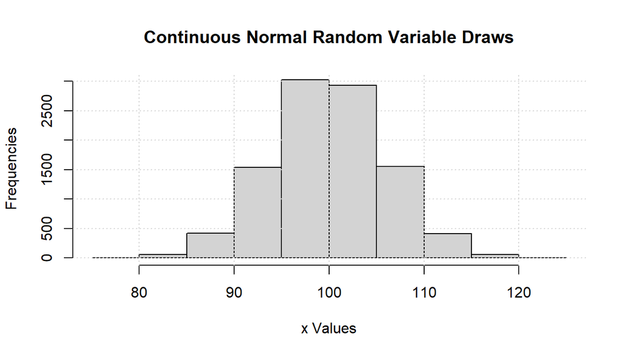

```r
# Random normal Data Vector (not equal outcomes)
set.seed(123)
it_sample_N <- 10000
fl_rnorm_mean <- 100
fl_rnorm_sd <- 6
ar_data_rnorm <- rnorm(it_sample_N, mean = fl_rnorm_mean, sd = fl_rnorm_sd)
# Visualize
par(new = FALSE)
hist(ar_data_rnorm, xlab = "x Values", ylab = "Frequencies", main = "")
title(main = "Continuous Normal Random Variable Draws")
grid()
```

We use the [binomial to approximate the normal distribution](https://en.wikipedia.org/wiki/Binomial_distribution). Let $\mu$ and $\sigma$ be the mean and standard deviations of the normal random variable, and $n$ and $p$ be the number of “trials” and the “probability-of-success” for the binomial distribution. We know that these relationships are approximately true, :

$$\begin{aligned}
\mu &= n\cdot p\\
n &= \frac{\mu}{p}\\
\sigma^2 &= n\cdot p\cdot(1-p) = \mu\cdot(1-p)\\
\end{aligned}$$

Given these, we have can translate between the normal random variable’s parameters and the binomial discrete random variable’s parameters:

$$\begin{aligned}
p &= 1 - \frac{\sigma^2}{\mu}\\
n &= \frac{\mu}{1 - \frac{\sigma^2}{\mu}} = \frac{\mu}{\frac{\mu - \sigma^2}{\mu}} = \frac{\mu^2}{\mu - \sigma^2}
\end{aligned}$$

There are two important aspects to note here:

1. Since $p$ must be positive, this means $\frac{\sigma^2}{\mu}<1$ and $\sigma^2<\mu$, which is the condition for the above transformation to work.
2. The binomial discrete random variable will have non-zero mass for very small probability events at the left-tail. These very low outcome events are highly unlikely to be observed or drawn from sampling the continuous random variable. The presence of these left-tail values might impact the computation of certain statistics, for example the [Atkinson Index for highly inequality averse planners](https://fanwangecon.github.io/R4Econ/math/func_ineq/htmlpdfr/fs_atkinson_ces.html).

Create a function for converting between normal and binomial parameters:

```r
ffi_binom_approx_nomr <- function(fl_rnorm_mean, fl_rnorm_sd) {
  #' @param fl_rnorm_mean float normal mean
  #' @param fl_rnorm_sd float normal standard deviation
  if (fl_rnorm_mean <= fl_rnorm_sd^2) {
    stop("Normal mean must be larger than the variance for conversion")
  } else {
    # Use binomial to approximate normal
    fl_p_binom <- 1 - fl_rnorm_sd^2 / fl_rnorm_mean
    fl_n_binom <- round(fl_rnorm_mean^2 / (fl_rnorm_mean - fl_rnorm_sd^2))
    fl_binom_mean <- fl_n_binom * fl_p_binom
    fl_binom_sd <- sqrt(fl_n_binom * fl_p_binom * (1 - fl_p_binom))
    # return
    return(list(
      fl_p_binom = fl_p_binom, fl_n_binom = fl_n_binom,
      fl_binom_mean = fl_binom_mean, fl_binom_sd = fl_binom_sd
    ))
  }
}
```

Call the function to generate binomial parameters:

```r
# with these parameters, does not work
ls_binom_params <- ffi_binom_approx_nomr(fl_rnorm_mean = 10, fl_rnorm_sd = 3)
# Call function with parameters, defined earlier, that work
ls_binom_params <- ffi_binom_approx_nomr(fl_rnorm_mean, fl_rnorm_sd)
fl_binom_mean <- ls_binom_params$fl_binom_mean
fl_binom_sd <- ls_binom_params$fl_binom_sd
fl_n_binom <- ls_binom_params$fl_n_binom
fl_p_binom <- ls_binom_params$fl_p_binom
# Mean and sd
print(paste0("BINOMI mean=", ls_binom_params$fl_binom_mean))
```

```
## [1] "BINOMI mean=99.84"
```

```r
print(paste0("BINOMI mean=", ls_binom_params$fl_binom_sd))
```

```
## [1] "BINOMI mean=5.99519807846246"
```

```r
# drv = discrete random variable
ar_drv_rbinom_xval <- seq(1, fl_n_binom)
ar_drv_rbinom_prob <- dbinom(ar_drv_rbinom_xval,
  size = fl_n_binom, prob = fl_p_binom
)
# ignore weight at x=0
ar_drv_rbinom_prob <- ar_drv_rbinom_prob / sum(ar_drv_rbinom_prob)
```

Visualize the binomial discrete random variable:

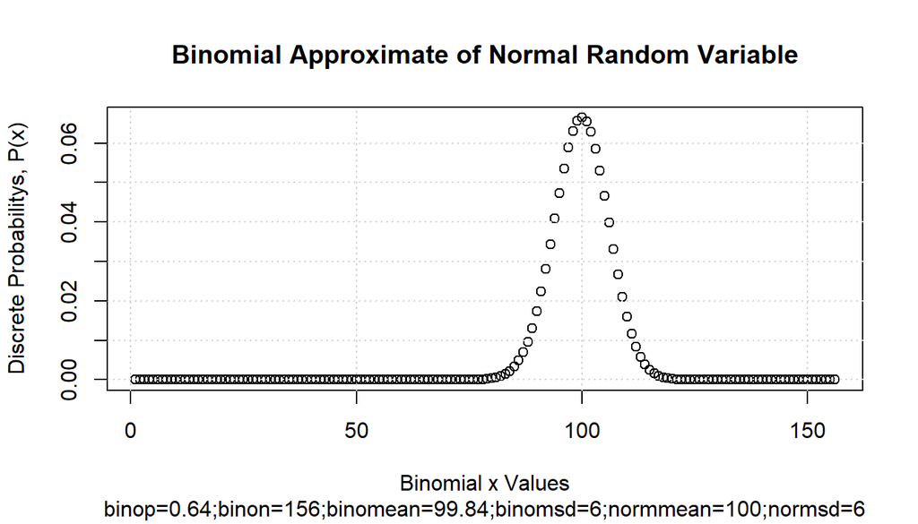

```r
# graph
par(new = FALSE)
ar_ylim <- c(0, 1)
plot(ar_drv_rbinom_xval, ar_drv_rbinom_prob,
  xlab = "Binomial x Values", ylab = "Discrete Probabilitys, P(x)"
)
title(
  main = paste0("Binomial Approximate of Normal Random Variable"),
  sub = paste0(
    "binop=", round(fl_p_binom, 2),
    ";binon=", round(fl_n_binom, 2),
    ";binomean=", round(fl_binom_mean, 2),
    ";binomsd=", round(fl_binom_sd, 2),
    ";normmean=", round(fl_rnorm_mean, 2), ";normsd=", round(fl_rnorm_sd, 2)
  )
)
grid()
```